# aragongonzalezgonzalez_taller3

Taller 3 — Taller de Programación R

Mauricio J. Aragón R. — 201729052  
Alejandra González - 202111607  
Valentina González - 202111608

Mayo 2026

[figure not shown]

**Nota sobre uso de IA:** Se anexa un documento adicional con las conversaciones sostenidas con agentes de IA en caso de que se hayan utilizado para desarrollar el taller.

# Ejercicio 1: Datos Geoespaciales (1.5 puntos)

Elaborarán un mapa en el cual se visualizará el Índice de Desempeño Fiscal (IDF) del DNP por departamento. Para esto, utilizarán tres fuentes de datos:

- `IDF.xlsx` generado por el [DNP](https://ciffit.dnp.gov.co/CIFFIT/ConsultasIDF)
- Shapefile a nivel departamental y municipal generado por el [DANE](https://geoportal.dane.gov.co/servicios/descarga-y-metadatos/datos-geoestadisticos/?cod=111)
- `proyección poblacional.xlsx` cuya fuente es el [DANE](https://www.dane.gov.co/files/censo2018/proyecciones-de-poblacion/Municipal/PPED-AreaMun-2018-2042_VP.xlsx)
- Valor agregado municipal, cuya fuente es el [DANE](https://www.dane.gov.co/index.php/estadisticas-por-tema/cuentas-nacionales/cuentas-nacionales-departamentales)

Sean cuidadosos con las llaves que usan para unir las bases de datos. Recuerden manipular adecuadamente las tres bases de datos y estudiar la estructura que tiene cada una. **No deben modificar o sobreescribir información directamente sobre los archivos**. Todo el tratamiento de datos debe hacerse dentro de R.

```r
#Primero cargamos la del IDF
#Usar el nombre con el que tengan disponible la consulta del DNP
df_idf <- read_excel(
  "ConsultaIDF_2024.xlsx",
  skip = 16
) %>% rename(MPIO = `Código Entidad`)

#Segundo cargamos la de población para 2024 y solo los totales
df_pop <- read_excel(
  "PPED-AreaMun-2018-2042_VP.xlsx",
  sheet = "PobMunicipalxÁrea",
  skip = 7
) %>% filter(AÑO==2024) %>% filter(`ÁREA GEOGRÁFICA` == "Total")

#Tercero cargamos el valor agregado municipal (pesos corrientes)
df_va <- read_excel(
  "anex-PIBDep-ValorAgreMuni-2011-2023p.xlsx",
  sheet = "Cuadro 14",
  skip = 10
) %>% filter(!is.na(Municipio)) %>% rename(MPIO = `Código Municipio`)

#Cuarto hacemos el junte de las bases de datos

df <- df_idf %>% left_join(df_pop, by = "MPIO") %>% rename(Poblacion = TOTAL) %>%
  left_join(df_va, by = "MPIO")

base_mun <- df %>% select(DP, DPNOM, MPIO, DPMP, IDF,
                      Poblacion, `Valor agregado\r\n`, Rango) %>%
  rename(VA = `Valor agregado\r\n`)
```

**Uso IA:** Revisar el documento anexo en donde se detalla la conversación para usar `read_excel`.

## Literal A. (1.0)

Para este primer ejercicio, crearán un índice artificial para agregar los datos por departamento, cuya ponderación se realizará por valor agregado per cápita. Es decir, usará la siguiente fórmula:

$$\text{IDF}_j = \sum_{i=1}^n \text{IDF}_i \times \frac{L_i \times \text{VA}_i}{\Sigma_j}$$

donde:

- $\text{IDF}_j$: Es el Índice de Desempeño Fiscal artificial del departamento $j$
- $\text{IDF}_i$: Es el Índice de Desempeño Fiscal real del municipio $i$ dentro del departamento $j$
- $L_i$: Población del municipio $i$
- $\text{VA}_i$: Es el valor agregado del municipio $i$
- $\Sigma_j$: Se define como $\Sigma_j = \sum_i^n \text{VA}_i \times L_i$
- $n$ Número de municipios en el departamento $j$

Por otro lado, nuestro objetivo será aplicar la fórmula para el 2024. Para esto **apliquen el crecimiento del PIB de Colombia en el 2024** (no el $\text{VA}_i$) al crecimiento del $\text{VA}_i$ por municipio, cuyo último dato está en el 2023. Calculen ese crecimiento solo con dos decimales (ejemplo 2.85%) para el cálculo del nuevo $\text{VA}_i$.

```r
# Ajustamos el VA a 2024


# Comenzamos por adicionar la variable L x VA
base_mun_ind <- base_mun %>% mutate(PobxVA = Poblacion * VA)

# La agregamos a nivel departamental
base_d <- base_mun_ind %>% group_by(DP) %>% summarise(
  sum(PobxVA, na.rm = TRUE))

# La añadimos a la base municipal
base_mun_ind <- base_mun_ind %>% left_join(base_d, by="DP") %>%
  rename(PobxVA_Dep = `sum(PobxVA, na.rm = TRUE)`) %>%
  # Creamos la variable departamental que se debe agregar
  mutate(ind_dep = IDF * PobxVA / PobxVA_Dep)

# Armamos la base departamental
base_dep <- base_mun_ind %>% group_by(DP, DPNOM) %>% summarise(IDF_dep =
  sum(ind_dep, na.rm = TRUE), .groups = "drop")

# Añadimos el factor de rango para los mapas
base_dep <- base_dep %>%
  mutate(Rango = case_when(
      IDF_dep < 40 ~ 1,
      IDF_dep >= 40 & IDF_dep < 60 ~ 2,
      IDF_dep >= 60 & IDF_dep < 70 ~ 3,
      IDF_dep >= 70 & IDF_dep < 80 ~ 4,
      IDF_dep >= 80 ~ 5
    )
  ) %>% mutate(Rango_Cat = factor(
    Rango,
    levels = c(1,2,3,4,5),
    labels = c("Deterioro", "Riesgo", "Vulnerable", "Solvente", "Sostenible")
  ))
```

Una vez obtenido el índice por departamento, crearán un gráfico utilizando todos los elementos estéticos que permitan una correcta visualización y realizarán una interpretación del mismo. Este debe incluir elementos como un título descriptivo, una leyenda clara, una escala de colores apropiada y cualquier otro elemento que se considere relevante para facilitar la interpretación de los resultados.

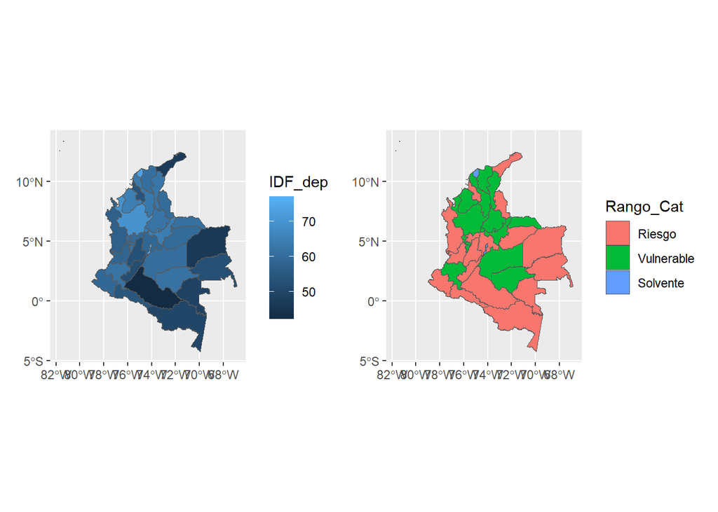

```r
# Cargamos los datos geoespaciales
shapefile_path <- "MGN2025_DPTO_POLITICO"
crs <- "+proj=longlat +datum=WGS84"  # Proyección WGS84
sf_data <- st_read(dsn = shapefile_path) %>% rename(DP = dpto_ccdgo) %>%
  left_join(base_dep, by = "DP")
# Mapa
IDF_DPTOS <- ggplot() +
  geom_sf(data = sf_data, aes(fill = IDF_dep))

IDF_DPTOS_cat <- ggplot() +
  geom_sf(data = sf_data, aes(fill = Rango_Cat))

Grafico1 <- IDF_DPTOS | IDF_DPTOS_cat

print(Grafico1)
```

## Literal B (0.5)

Intenten realizar un gráfico del IDF por municipio, pero no es necesario presentarlo en el documento. ¿Qué problemas encuentran al intentar realizarlo? expliquen por qué pasa esto.

```r
#
```

# Ejercicio 2: Web Scraping y Uso de API (2.0)